# Acute vs. culture patchseq comparison

Now let’s look at the topLeaf score, only for cells mapping to a leaf node.

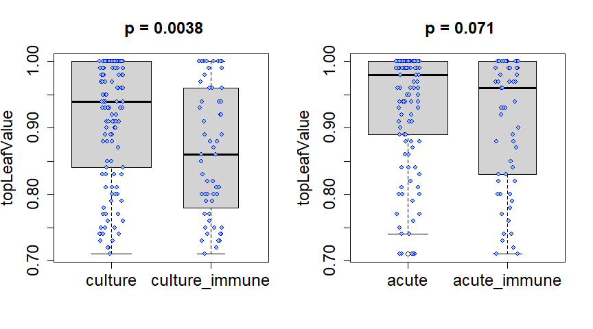

```r
col = "topLeafValue"
kp  = metaPatch$res_index==1
par(mfrow=c(1,2))
kpc <- grepl("culture",patch$condition2)&(!is.na(metaPatch[,col]))&kp
kpa <- (!grepl("culture",patch$condition2))&(!is.na(metaPatch[,col]))&kp
verboseBoxplot(metaPatch[,col][kpc],patch$condition2[kpc], notch=FALSE, xlab="", ylab=col,addScatterplot = TRUE)
verboseBoxplot(metaPatch[,col][kpa],patch$condition2[kpa], notch=FALSE, xlab="", ylab=col,addScatterplot = TRUE)
```

There is slightly lower mapping confidence in the immune signature cells even for cells mapping to a leaf node (with the caveat that by definition all values are >0.7, and all values are quite good).

Plot markers by subclass in acute, culture, immune, and non-immune. Recall that the marker genes were extracted above.

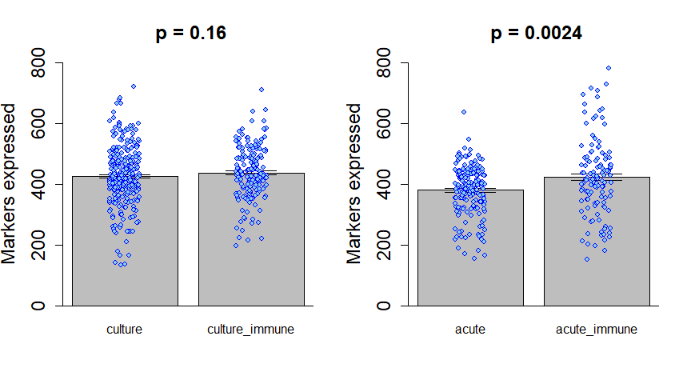

```r
par(mfrow=c(1,2))
kpc <- grepl("culture",patch$condition2)
kpa <- (!grepl("culture",patch$condition2))
verboseBarplot(colSums(datPatch[markers,kpc]>0),patch$condition2[kpc], xlab="", ylab="Markers expressed",addScatterplot = TRUE,ylim=c(0,800))
verboseBarplot(colSums(datPatch[markers,kpa]>0),patch$condition2[kpa], xlab="", ylab="Markers expressed",addScatterplot = TRUE,ylim=c(0,800))
```

The number of marker genes detected is approximately the same in immune vs. non-immune suggesting the increase in genes is a different gene set. For each subclass, let’s see how well the genes are correlated when considering marker genes. We’ll also plot the immune signature genes for comparison, but these genes will not go into the correlation calculations.

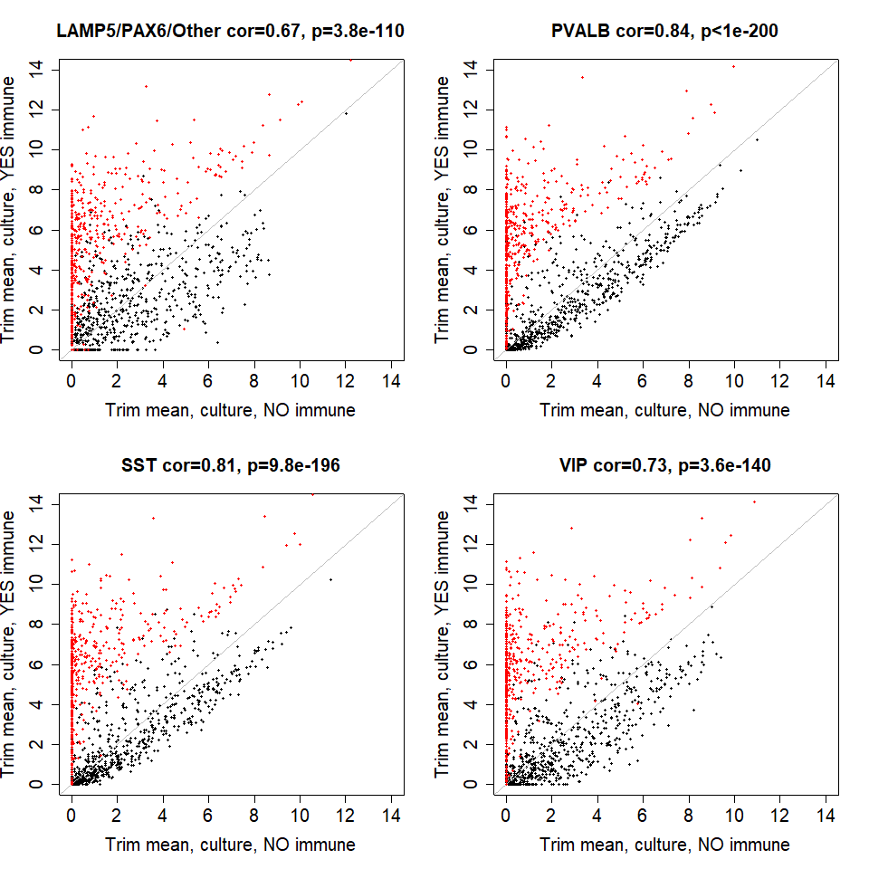

```r
dat <- as.matrix(datPatch[markers,])
dat_immune <- as.matrix(datPatch[is_immune,])
subclass   <- metaPatch$subclass_label
pc  <- patch$condition2
par(mfrow=c(2,2))
for (s in sort(unique(subclass))){
  datI <- apply(dat[,(pc=="culture_immune")&(subclass==s)],1,function(x) mean(x,trim=0.25))
  datN <- apply(dat[,(pc=="culture")&(subclass==s)],1,function(x) mean(x,trim=0.25))
  verboseScatterplot(datN,datI,xlab="Trim mean, culture, NO immune",ylab="Trim mean, culture, YES immune",
                     main=s,pch=19,cex=0.5,xlim=c(0,14),ylim=c(0,14))
  abline(0,1,col="grey")

  datIi <- apply(dat_immune[,(pc=="culture_immune")&(subclass==s)],1,function(x) mean(x,trim=0.25))
  datNi <- apply(dat_immune[,(pc=="culture")&(subclass==s)],1,function(x) mean(x,trim=0.25))
  points(datNi,datIi,pch=19,cex=0.5,col="red")
}

set.seed(42)
pci  <- sample(pc,length(pc))
par(mfrow=c(2,2))
```

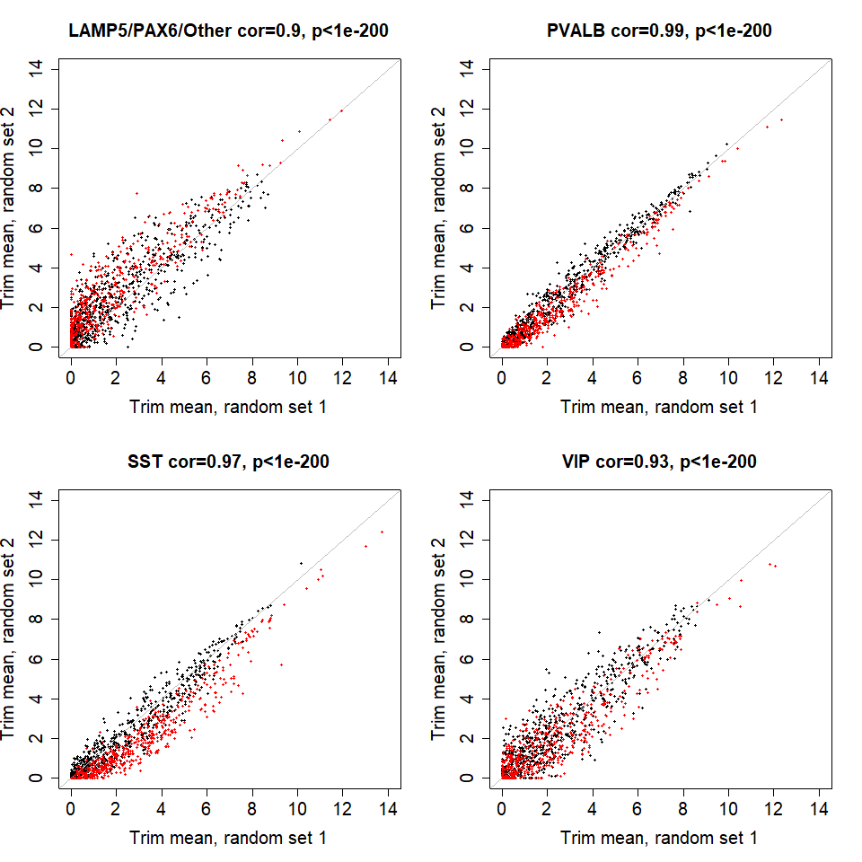

```r
for (s in sort(unique(subclass))){
  datI <- apply(dat[,(pci=="culture_immune")&(subclass==s)],1,function(x) mean(x,trim=0.25))
  datN <- apply(dat[,(pci=="culture")&(subclass==s)],1,function(x) mean(x,trim=0.25))
  verboseScatterplot(datN,datI,xlab="Trim mean, random set 1",ylab="Trim mean, random set 2",
                     main=s,pch=19,cex=0.5,xlim=c(0,14),ylim=c(0,14))
  abline(0,1,col="grey")

  datIi <- apply(dat_immune[,(pci=="culture_immune")&(subclass==s)],1,function(x) mean(x,trim=0.25))
  datNi <- apply(dat_immune[,(pci=="culture")&(subclass==s)],1,function(x) mean(x,trim=0.25))
  points(datNi,datIi,pch=19,cex=0.5,col="red")
}
```

## Compare immune status by donor

In this section we want to see whether any donor or cell properties relate to the immune signature.

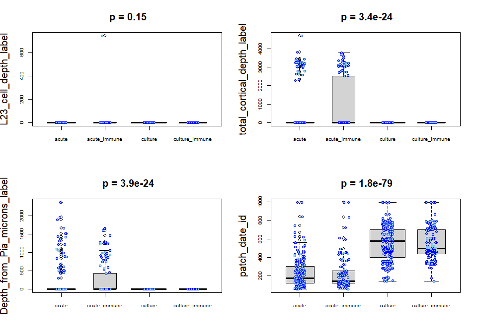

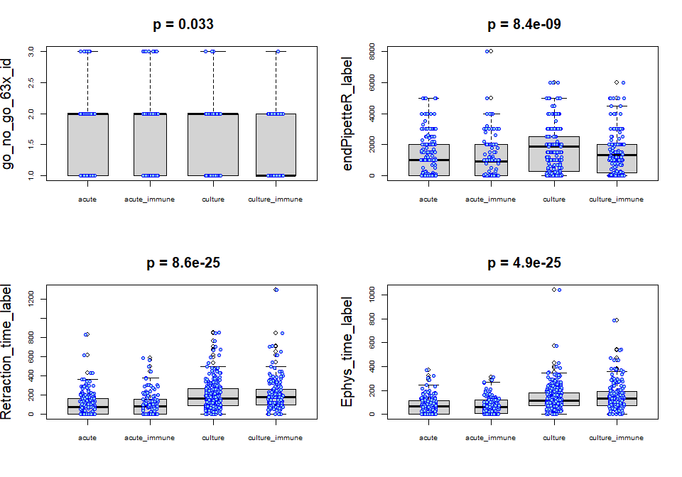

```
[1] "Region"
                  y
x                  acute acute_immune culture culture_immune
                      12           10       0              0
  AnG                  3            1       4              1
  AOrG                 0            0      12              4
  CgGr                 0            0      13              1
  FroL                 5            6      27             10
  Frontal              0            1       3              2
  IFG                  3            1       0              0
  IFGtr                1            1       0              0
  ITG                  8            3      16              5
  LOrG                 0            1       0              0
  MFG                 12            0       7              3
  MTG                 72           60     115             86
  OccL                 0            0       3              2
  PaCG                 3            2      13             11
  Parieto-temporal     2            1       0              0
  ParL                 0            0      12              3
  PLP                  2            0       0              0
  PRG                  5            4       0              0
  SFG                 16            9      20             18
  SOG                  0            0       1              1
  SPL                  2            4       0              0
  STG                 15            5       4              7
  TemL                27           15      38             24
[1] "sliceHealth_label"
            y
x            acute acute_immune culture culture_immune
  0              1            0       0              0
  1             10            9      24             10
  2             52           26      88             44
  3             61           39     110             90
  4             21           25      55             28
  5              8            2       3              0
  ZZ_Missing    35           23       8              6
[1] "rigNumber_color"
         y
x         acute acute_immune culture culture_immune
  #000004    44           26       0              0
```

[output cut: 200 more lines]

```
  Epilepsy                          89           70      74             58
  Epileptiform Events                1            1      26             11
  Tumor                             19            8       3              1
  Tumor-Brain                        0            0      26             12
  Tumor status - primary             8            3       8              6
  Tumor status - recurrent           0            0       4              1
  ZZ_Missing                        24            9      43             26
[1] "gender_label"
            y
x            acute acute_immune culture culture_immune
                90           53      19             17
  F             28           14      78             32
  FALSE          2            1      19             13
  M             33           26     168            114
  ZZ_Missing    35           30       4              2
```

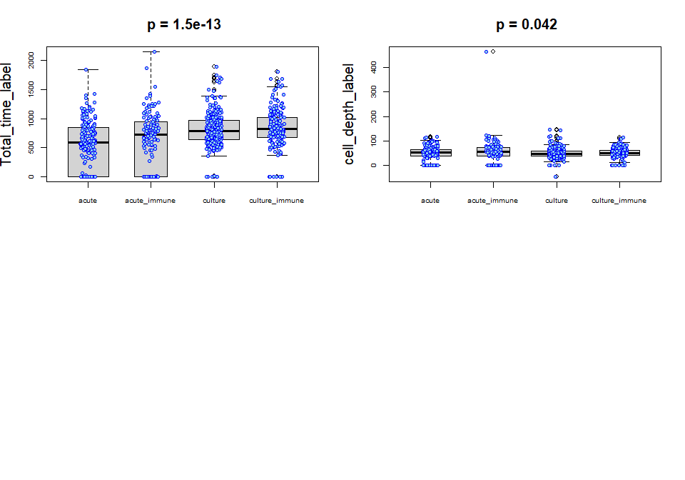

```r
annoPatch$patch_year = substr(annoPatch$patch_date_label,1,4)
annoPatch$Region     = metaPatch$structure
annoPatch$Donor      = metaPatch$Donor
cols <- c("L23_cell_depth_label", "total_cortical_depth_label", "Depth_from_Pia_microns_label", "patch_date_id",
          "go_no_go_63x_id", "endPipetteR_label", "Retraction_time_label", "Ephys_time_label", "Total_time_label",
          "Region", "cell_depth_label", "sliceHealth_label", "rigNumber_color", "Donor","patch_year",
          "postPatch_classification_label", "postPatch_label", "medical_conditions_label", "gender_label")
par(mfrow=c(2,2))
for (col in cols){
  x <- annoPatch[,col]
  kp<- !is.na(x)
  y <- patch$condition2[kp]
  x <- x[kp]
  if(is.numeric(x)){
    verboseBoxplot(x,y, notch=FALSE, xlab="", ylab=col,addScatterplot = TRUE, cex.axis=0.75)
  } else {
    print(col)
    print(table(x,y))
  }
}
```

There are no super obvious differences between the immune and non-immune cells, although there are some subtle hints. For example, this effect might be more prevalent in male than female individuals, and not all donors have an equal split of yes/no calls.

# Double bouquet cell DEX

In a separate analysis we found that DBCs fall in two clusters with equal frequency to non-DBCs in those same clusters. The question we want to ask now is, given the cell morphology, can we find any DEX genes between DBCs and non-DBCs that are mapped to either Inh L1-3 SST CALB1 or Inh L3-5 SST ADGRG6. Since we are only looking at patch-seq data, we don’t need to restrict the analysis to “keepGenes” defined above.

```r
dbc_info <- read.csv("dbc_calb1_ADGRG6.csv")
dbc_dat  <- datPatch[,dbc_info$Tube_id]
dbc_dat  <- dbc_dat[rowSums(dbc_dat>3)>=6,]  # Request expression>3 in at least 5/28 total cells in analysis
dbc      <- dbc_info$DBC=="yes"

wilcox_plus <- function(xy,split){
  x <- xy[split]
  y <- xy[!split]
  w <- suppressWarnings(wilcox.test(x, y))
  signif(c(mean(x),sd(x),sum(x>0),mean(y),sd(y),sum(y>0),mean(x)-mean(y),w$statistic,w$p.value),3)
}
dbc_stats <- t(apply(dbc_dat,1,wilcox_plus,dbc))
dbc_stats <- data.frame(cbind(dbc_stats,p.adjust(dbc_stats[,9],method = "fdr",n=length(dbc_stats[,9]))))
colnames(dbc_stats) <- c("mean_dbc","sd_dbc","count_dbc","mean_nondbc","sd_nondbc","count_nondbc",
                         "logfc","wilcox_stat","wilcox_pval","wilcox_FDR")

head(dbc_stats[order(dbc_stats[,7]),],20)
```

|  | mean_dbc | sd_dbc | count_dbc | mean_nondbc | sd_nondbc | count_nondbc | logfc | wilcox_stat | wilcox_pval | wilcox_FDR |
| --- | --- | --- | --- | --- | --- | --- | --- | --- | --- | --- |
| CCL2 | 3.140 | 4.64 | 4 | 7.60 | 4.47 | 14 | -4.46 | 46.5 | 0.02520 | 0.9390654 |
| DNAJC15 | 1.970 | 2.86 | 4 | 5.95 | 1.96 | 16 | -3.98 | 26.5 | 0.00155 | 0.9390654 |
| S100A9 | 2.270 | 3.93 | 3 | 5.81 | 4.14 | 12 | -3.54 | 52.0 | 0.04210 | 0.9390654 |
| PDLIM5 | 2.830 | 3.14 | 6 | 6.26 | 1.86 | 17 | -3.44 | 33.0 | 0.00465 | 0.9390654 |
| RER1 | 2.700 | 3.18 | 5 | 6.03 | 2.07 | 16 | -3.32 | 40.0 | 0.01200 | 0.9390654 |
| CD44 | 1.410 | 3.10 | 3 | 4.71 | 4.64 | 9 | -3.30 | 64.0 | 0.13100 | 0.9390654 |
| CCT5 | 3.710 | 3.24 | 8 | 6.97 | 1.93 | 16 | -3.26 | 30.5 | 0.00324 | 0.9390654 |
| NIF3L1 | 0.377 | 1.25 | 1 | 3.60 | 3.03 | 11 | -3.23 | 37.0 | 0.00350 | 0.9390654 |
| VIM | 2.360 | 4.14 | 3 | 5.57 | 4.01 | 12 | -3.20 | 56.0 | 0.06660 | 0.9390654 |
| CHI3L1 | 1.070 | 2.09 | 3 | 4.26 | 4.81 | 8 | -3.18 | 63.0 | 0.10900 | 0.9390654 |

[output cut: 10 more lines]

```r
head(dbc_stats[order(-dbc_stats[,7]),],20)
```

|  | mean_dbc | sd_dbc | count_dbc | mean_nondbc | sd_nondbc | count_nondbc | logfc | wilcox_stat | wilcox_pval | wilcox_FDR |
| --- | --- | --- | --- | --- | --- | --- | --- | --- | --- | --- |
| SLC25A27 | 6.49 | 1.20 | 11 | 2.650 | 2.85 | 10 | 3.84 | 160 | 0.001760 | 0.9390654 |
| KHDRBS2 | 8.40 | 1.23 | 11 | 4.580 | 3.59 | 12 | 3.82 | 154 | 0.004650 | 0.9390654 |
| KIAA1147 | 5.32 | 2.16 | 10 | 1.520 | 2.09 | 8 | 3.79 | 162 | 0.001160 | 0.9390654 |
| ERRFI1 | 7.19 | 2.05 | 11 | 3.500 | 2.72 | 12 | 3.69 | 163 | 0.001140 | 0.9390654 |
| CES4A | 5.88 | 1.41 | 11 | 2.420 | 2.67 | 9 | 3.46 | 156 | 0.003170 | 0.9390654 |
| BRINP1 | 7.54 | 1.54 | 11 | 4.130 | 2.69 | 15 | 3.41 | 161 | 0.001620 | 0.9390654 |
| GBA2 | 6.33 | 1.43 | 11 | 2.960 | 2.98 | 9 | 3.37 | 152 | 0.005780 | 0.9390654 |
| CBLN4 | 7.11 | 1.39 | 11 | 3.780 | 3.17 | 11 | 3.33 | 152 | 0.006120 | 0.9390654 |
| SNPH | 4.59 | 2.56 | 9 | 1.270 | 2.01 | 6 | 3.32 | 153 | 0.003450 | 0.9390654 |
| SPIN3 | 3.82 | 2.88 | 8 | 0.498 | 1.29 | 3 | 3.32 | 154 | 0.001360 | 0.9390654 |

[output cut: 10 more lines]

```r
write.csv(dbc_stats[order(dbc_stats[,7]),],"DBC_DE_statistics.csv")
```

There are no significant differentially expressed genes. We’ll use some web tools (e.g., ToppGene) to see if we can learn anything else.

Let’s try another strategy of collecting all cells in these two cell types and see if we can use random forest to predict the other cells. We are likely extremely underpowered for that, but it’s worth a try…

```r
all_immune <- sort(union(rownames(culture_immune), rownames(acute_immune)))
kpDBC  <- is.element(metaPatch$topLeaf_label,c("Inh L1-3 SST CALB1","Inh L3-5 SST ADGRG6"))
datDBC <- datPatch[setdiff(names(keepGenes),all_immune),kpDBC]
morph  <- metaPatch$morpho_call[kpDBC]
morph[morph==""] = "Unknown"
morph[is.element(morph,c("MC","Basket","Sparse SST"))] = "Not DBC"

dbcGenes <- VariableFeatures(FindVariableFeatures(CreateSeuratObject(datDBC),verbose=FALSE,nfeatures = 2500))
datExpr <- cbind(data.frame(morph=morph),t(datDBC[dbcGenes,]))
datExpr$morph <- droplevels(as.factor(datExpr$morph))
genes   <- setNames(colnames(datExpr),make.names(colnames(datExpr)))
colnames(datExpr) <- names(genes)

runs        <- 10
importance  <- list()
predictions <- matrix(NA,nrow = dim(datExpr)[1],ncol=runs)
rownames(predictions) <- rownames(datExpr)

for (seed in 1:runs){
  set.seed(seed)
  sample <- subsampleCells(datExpr$morph, 3, seed=seed)
  sample[is.element(morph,c("Unknown","Basket"))] = 0

  train  <- subset(datExpr, sample == 1)
  train$morph <- droplevels(train$morph)
  test   <- subset(datExpr, sample != 1)
  rf     <- randomForest(morph ~ ., data=train, importance=TRUE)
  pred   <- predict(rf, newdata=test[-1])  # the first column is donor name
  importance[[seed]] <- rf$importance
  rownames(importance[[seed]]) <- as.character(genes[rownames(importance[[seed]])])
  predictions[names(pred),seed] = as.character(pred)
}
pred  <- apply(predictions,1,function(x) names(sort(-table(x)))[1])
score <- apply(predictions,1,function(x) max(table(x))/sum(table(x)))
table(morph,pred)
```

```
         pred
morph     DBC Not DBC
  DBC       9       2
  Not DBC   3       7
  Unknown  50      24
```

```r
meanImportance <- pmean.fromList(importance)
```

These results aren’t terrible, and seem generally believable (with the exception that we are assuming the basket cell is an anomaly). Now let’s run a DEX analysis of predicted DBCs vs. non-DBCs.

```r
dbc_stats2 <- t(apply(datDBC[setdiff(keepGenes,all_immune),],1,wilcox_plus,(pred=="DBC")))
dbc_stats2 <- data.frame(cbind(dbc_stats2,p.adjust(dbc_stats2[,9],method = "fdr",n=length(dbc_stats2[,9]))))
colnames(dbc_stats2) <- c("mean_dbc","sd_dbc","count_dbc","mean_nondbc","sd_nondbc","count_nondbc",
                         "logfc","wilcox_stat","wilcox_pval","wilcox_FDR")

head(dbc_stats2[order(dbc_stats2[,7]),],20)
```

|  | mean_dbc | sd_dbc | count_dbc | mean_nondbc | sd_nondbc | count_nondbc | logfc | wilcox_stat | wilcox_pval | wilcox_FDR |
| --- | --- | --- | --- | --- | --- | --- | --- | --- | --- | --- |
| DRAM1 | 1.120 | 2.02 | 21 | 5.27 | 2.62 | 29 | -4.15 | 281 | 8.75e-10 | 3.931838e-07 |
| BAG3 | 0.396 | 1.09 | 8 | 4.49 | 2.84 | 26 | -4.10 | 269 | 6.49e-12 | 2.032738e-08 |
| POLR2G | 2.530 | 2.78 | 32 | 6.21 | 2.03 | 32 | -3.68 | 286 | 4.65e-09 | 1.315606e-06 |
| IGSF21 | 1.600 | 1.96 | 30 | 5.24 | 2.35 | 30 | -3.65 | 268 | 1.44e-09 | 5.500080e-07 |
| PPP1R18 | 0.671 | 1.54 | 13 | 4.27 | 2.52 | 26 | -3.60 | 316 | 6.09e-10 | 3.171921e-07 |
| C10orf11 | 3.110 | 2.38 | 46 | 6.67 | 3.02 | 29 | -3.56 | 347 | 1.13e-07 | 1.598531e-05 |
| WIPF1 | 1.800 | 2.07 | 34 | 5.25 | 1.73 | 32 | -3.45 | 242 | 6.05e-10 | 3.171921e-07 |
| SHMT2 | 1.090 | 2.24 | 14 | 4.52 | 2.81 | 25 | -3.43 | 424 | 1.55e-07 | 2.018259e-05 |
| ABCA1 | 3.030 | 2.43 | 45 | 6.44 | 2.40 | 31 | -3.41 | 274 | 4.25e-09 | 1.232877e-06 |
| FUCA2 | 2.630 | 2.81 | 32 | 5.98 | 2.80 | 28 | -3.36 | 370 | 1.67e-07 | 2.150078e-05 |

[output cut: 10 more lines]

```r
head(dbc_stats2[order(-dbc_stats2[,7]),],20)
```

|  | mean_dbc | sd_dbc | count_dbc | mean_nondbc | sd_nondbc | count_nondbc | logfc | wilcox_stat | wilcox_pval | wilcox_FDR |
| --- | --- | --- | --- | --- | --- | --- | --- | --- | --- | --- |
| EPHB6 | 6.67 | 1.790 | 61 | 3.61 | 2.35 | 25 | 3.05 | 1800 | 1.04e-09 | 4.496921e-07 |
| LOC642776 | 7.54 | 1.390 | 61 | 4.54 | 2.93 | 25 | 3.00 | 1820 | 5.75e-10 | 3.137446e-07 |
| MIR124-2HG | 5.74 | 2.230 | 58 | 2.76 | 2.33 | 21 | 2.98 | 1710 | 7.50e-08 | 1.177243e-05 |
| KAZN | 11.30 | 0.888 | 62 | 8.41 | 2.17 | 33 | 2.91 | 1920 | 1.84e-12 | 2.032738e-08 |
| GRIP1 | 10.30 | 0.841 | 62 | 7.45 | 2.73 | 32 | 2.87 | 1860 | 5.32e-11 | 6.095922e-08 |
| CDC25B | 5.19 | 2.380 | 56 | 2.33 | 2.03 | 23 | 2.86 | 1670 | 3.91e-07 | 4.159011e-05 |
| SNORD115@ | 8.80 | 1.290 | 62 | 5.93 | 2.26 | 31 | 2.86 | 1870 | 2.98e-11 | 4.017215e-08 |
| ADGRB3 | 9.08 | 1.290 | 62 | 6.24 | 2.85 | 30 | 2.84 | 1770 | 5.13e-09 | 1.402302e-06 |
| SLC8A3 | 7.14 | 1.750 | 60 | 4.31 | 2.70 | 26 | 2.83 | 1770 | 5.83e-09 | 1.518251e-06 |
| FLT3 | 4.99 | 2.660 | 56 | 2.16 | 2.28 | 21 | 2.82 | 1600 | 6.61e-06 | 4.039503e-04 |

[output cut: 10 more lines]

```r
write.csv(dbc_stats2[order(dbc_stats2[,7]),],"DBC_DE_statistics2.csv")

rownames(metaPatch) <- colnames(datPatch)
table(pred,metaPatch[names(pred),"condition2"])
```

```
pred      acute acute_immune culture culture_immune
  DBC        11            3      46              2
  Not DBC     0            3       6             24
```

```r
table(morph,metaPatch[names(pred),"condition2"])
```

```
morph     acute acute_immune culture culture_immune
  DBC         3            1       4              3
  Not DBC     0            0       3              7
  Unknown     8            5      45             16
```

We cannot use genes to accurately predict DBC vs. non-DBC because 4/11 DBCs are immune, while 7/9 MCs+SMCs are immune, and the prediction algorithm almost entirely divides by this source of variation, even after attempting to account for it.

### Comparison of morphology, electrophysiology, and transcriptomics of L1-3 SST CALB1 cells

We cannot find many genes differentially expressed between morpho types, and the ones that we do find reflect differences in the count of cells with immune signatures. What if we restrict the space to cells in the immune culture group.

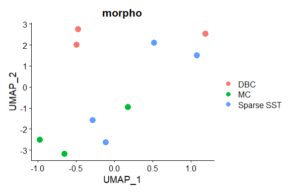

```r
kpMCI  <- is.element(metaPatch$topLeaf_label,c("Inh L1-3 SST CALB1"))#,"Inh L3-5 SST ADGRG6"))
kpMCI  <- kpMCI&(metaPatch$condition2=="culture_immune")&!(is.element(metaPatch$morpho_call,c("","Unknown")))
offMCI <- rownames(datPatch)[rowMedians(datPatch[,kpMCI])<1]
kpGnMCI<- setdiff(names(keepGenes)[keepGenes],c(all_immune,offMCI))
datMCI <- datPatch[kpGnMCI,kpMCI]  # Exclude immune genes again, as well as genes not expressed in half the cells

metadataMCI <- data.frame(morpho = metaPatch$morpho_call[kpMCI])
rownames(metadataMCI) <- colnames(datMCI)
mci <- CreateSeuratObject(counts = datMCI, meta.data = metadataMCI)
mci <- FindVariableFeatures(mci,nfeatures = 250, verbose = FALSE)
mci <- ScaleData(mci, verbose = FALSE)
mci <- RunPCA(mci, npcs = 5, verbose = FALSE)
mci2 <- RunUMAP(mci, reduction = "pca", dims = 1:5, verbose = FALSE, n.neighbors = 3)

DimPlot(mci2, reduction = "umap", group.by = "morpho",pt.size=4)
```

No separation by morphology using variable genes. What about by DEX genes?

```r
Idents(mci2) <- mci2$morpho
markersMCI  <- FindAllMarkers(mci2, verbose = FALSE, logfc.threshold = 0,test.use = "t", min.diff.pct = 0)
```

```r
print(dim(markersMCI))
```

```
[1] 253   7
```

```r
kpMCI  <- is.element(metaPatch$topLeaf_label,c("Inh L1-3 SST CALB1"))#,"Inh L3-5 SST ADGRG6"))
datMCI <- datPatch[,kpMCI]  # Exclude immune genes again, as well as genes not expressed in half the cells

metadataMCI <- data.frame(morpho = metaPatch$morpho_call[kpMCI],
                          condition2 = metaPatch$condition2[kpMCI],
                          celltype   = metaPatch$topLeaf_label[kpMCI])
metadataMCI$morpho[is.element(metadataMCI$morpho,c(""))]="Unknown"
rownames(metadataMCI) <- colnames(datMCI)
mci <- CreateSeuratObject(counts = datMCI, meta.data = metadataMCI)
VariableFeatures(mci) <- rownames(markersMCI)
mci <- ScaleData(mci, verbose = FALSE, features = VariableFeatures(mci))
pcs <- 6
mci <- RunPCA(mci, npcs = pcs, verbose = FALSE)
mci <- RunUMAP(mci, reduction = "pca", dims = 1:pcs, verbose = FALSE, n.neighbors = 5)

mci <- FindNeighbors(mci, verbose = FALSE, dims=1:2, reduction="umap")
```

```r
mci <- FindClusters(mci, verbose = FALSE, resolution=1)

a = range(FetchData(mci,c("UMAP_1","UMAP_2")))
p1=DimPlot(mci, reduction = "umap", group.by = "morpho",pt.size=4) + xlim(a) + ylim(a)
```

|  | t | l | b | r |
| --- | --- | --- | --- | --- |
| 1: | 1 | 1 | 1 | 1 |

```r
p2=DimPlot(mci, reduction = "umap", group.by = "condition2",pt.size=4) + xlim(a) + ylim(a)
```

|  | t | l | b | r |
| --- | --- | --- | --- | --- |
| 1: | 1 | 1 | 1 | 1 |

```r
p3=DimPlot(mci, reduction = "umap",pt.size=4) + xlim(a) + ylim(a)
```

|  | t | l | b | r |
| --- | --- | --- | --- | --- |
| 1: | 1 | 1 | 1 | 1 |

```r
print(p1+p2+p3)

pdf("cells_divided_by_morphology.pdf",height=4,width=15)
```

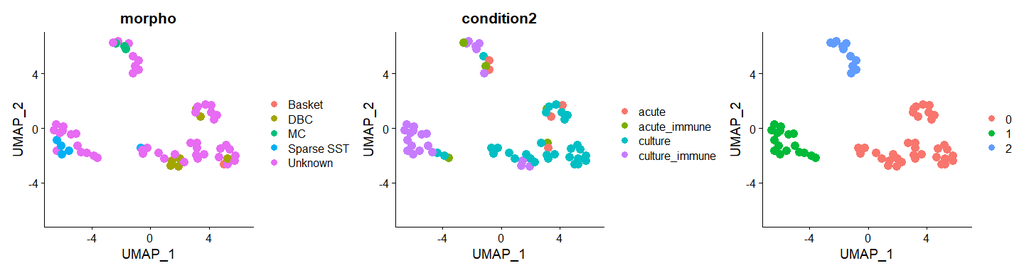

```r
print(p1+p2+p3)
dev.off()
```

There definitely appears to be a separation of cells by type when looking at the data this way, although this is somewhat circular. If we add the cells from ADGRG6, the results are still consistent and we have more data, which might be better.

Output the results to a file.

```r
morphoPred <- cbind(metadataMCI,Idents(mci),metaPatch$spec_id[kpMCI])
table(morphoPred$morpho,morphoPred[,4])
```

```
              0  1  2
  Basket      1  0  0
  DBC         7  0  0
  MC          0  0  3
  Sparse SST  1  4  0
  Unknown    27 13  8
```

```r
write.csv(morphoPred,"cell_morphology_predictions.csv")
```

Find genes differentially expressed between the three confirmed cell type groups.

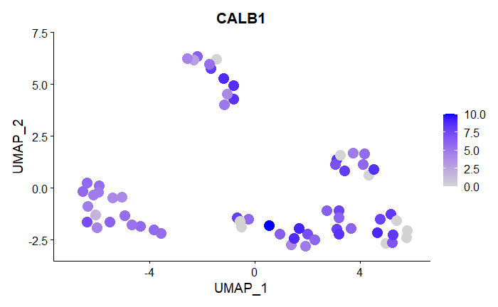

```r
FeaturePlot(mci,features = "CALB1",pt.size=5)
```

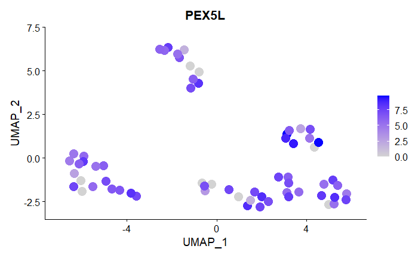

```r
FeaturePlot(mci,features = "PEX5L",pt.size=5)
```

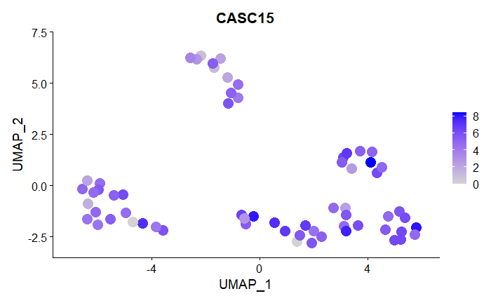

```r
FeaturePlot(mci,features = "CASC15",pt.size=5)
```

```r
mci3 <- mci[keepGenes,]
morphos <- as.numeric(as.character(Idents(mci3)))
morphos[morphos==0] = "DBC"
morphos[morphos==1] = "Sparse SST"
morphos[morphos==2] = "MC"
Idents(mci3) <- as.factor(morphos)
updated_markersMCI <- FindAllMarkers(mci3,only.pos=TRUE, verbose=FALSE, logfc.threshold = 1, min.diff.pct=0.2)
```

```r
updated_markersMCI <- updated_markersMCI[intersect(rownames(updated_markersMCI),rownames(datMCI)),] # Shouldn't be needed, but is

means <- findFromGroups(t(datMCI[rownames(updated_markersMCI),]),morphos)
colnames(means) <- paste(colnames(means)," (average)")
fracs <- findFromGroups(t(datMCI[rownames(updated_markersMCI),]>0),morphos)
colnames(fracs) <- paste(colnames(fracs),"(frac>0)")
out <- cbind(updated_markersMCI[c("cluster","p_val","p_val_adj","avg_log2FC")],means,fracs)
write.csv(out,"morphology_type_differential_genes.csv")
```

Read in electophysiology data and compare to morphology and transcriptomics.

```r
# Read in data
ephys  <- read.csv("acute.culture.locked_sstcalb1.ephys.csv")
info   <- read.csv("cell_morphology_predictions_CALB1.csv")
info   <- cbind(info,ephys[,c("Donor","structure","slice","Block","condition")])
info   <- info[match(ephys[,"spec_id"],info[,"cell.specimen.id"]),]
ephys  <- as.matrix(ephys[,12:104])
rownames(info) <- rownames(ephys) <- rownames(metadataMCI)
ephys  <- ephys[,colSums(is.na(ephys))<25]

# Find gene/ephys correlations
isVar  <- (rowSds(datMCI)>=1)&(rowMeans(datMCI>0)>=0.25)#&keepGenes
corVar <- cor(ephys,t(datMCI[isVar,]),use="p")
topVar <- which(abs(corVar)>=0.5,arr.ind = TRUE)
topVar <- apply(topVar,1,function(x) c(rownames(corVar)[x[1]],colnames(corVar)[x[2]],corVar[x[1],x[2]]))
topVar <- as.data.frame(t(topVar))
rownames(topVar) <- NULL
colnames(topVar) <- c("Feature","Gene","Correlation")
topVar[order(as.numeric(topVar$Correlation)),]
```

|  | Feature | Gene | Correlation |
| --- | --- | --- | --- |
| 696 | sag_tau | RAB12 | -0.709365765188667 |
| 652 | sag_tau | PEX5L | -0.696376516696367 |
| 930 | sag_area | YWHAH | -0.644161053340909 |
| 813 | latency_hero | SRSF9 | -0.632815331924639 |
| 238 | upstroke_rheo | EPB41L5 | -0.622317668333417 |
| 92 | peak_deltav_hero | CASC15 | -0.620047422295657 |
| 782 | sag_peak_t | SLC2A13 | -0.615514823097061 |
| 130 | sag_peak_t | CMTM8 | -0.609218762518328 |
| 248 | width_suprathresh_hero | ERP44 | -0.609025052116422 |
| 346 | sag_area | HP1BP3 | -0.606091130016133 |

[output cut: 965 more lines]

```r
write.csv(topVar,"top_ephys_gene_relationships_CALB1.csv",row.names=FALSE)

# Plot ephys vs. morpho relationships
pdf("ephys_box_plots.pdf",height=5,width=5)
for(i in 1:dim(ephys)[2]){
  x <- ephys[,i]
  verboseBoxplot(x[!is.na(x)],info$predicted.morpho[!is.na(x)],addScatterplot = TRUE, notch=FALSE,
                 pt.cex=(info$morpho[!is.na(x)]!="Unknown")+0.5, pt.col = labels2colors(info$morpho)[!is.na(x)],
                 pch=19,xlab="",ylab=colnames(ephys)[i])
}
dev.off()
```

Looking at the output plots by eye, I’m fairly confident that the predicted morphologies are NOT ACCURATE. In particular, the Sparse SST morphologies are very often outlier values from the other predicted Sparse SST calls, suggesting these predictions based on gene expression are wrong. What if we do the converse analysis, starting from ephys properties and seeing if there is any evidence of genes matching these new labels?

### Defining clusters based on ephys

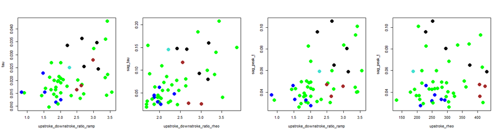

```r
# Plot some ephys variables
vf <- c("upstroke_downstroke_ratio_ramp", "peak_deltav_ramp", "upstroke_downstroke_ratio_rheo", "upstroke_rheo", "upstroke_hero", "downstroke_short_square", "sag_tau", "tau", "sag_peak_t")
e <- rbind(c(vf[1],vf[8]), c(vf[3],vf[7]), c(vf[1],vf[9]), c(vf[4],vf[9]))
par(mfrow=c(1,4))
for (i in 1:4){
  cols <- gsub("yellow","black",labels2colors(info$morpho))
  plot(ephys[,e[i,1]],ephys[,e[i,2]],col=cols,pch=19,xlab=e[i,1],ylab=e[i,2],cex=2)
}
```

```r
# Perfect separation based on upstroke_rheo and sag_peak_t
new_prediction <- mci$morpho
new_prediction[ephys[,"sag_peak_t"]<=100]   = "DBC"
new_prediction[ephys[,"upstroke_rheo"]>350] = "MC"
new_prediction[ephys[,"sag_peak_t"]>0.053]  = "Sparse SST"

#varGn <- intersect(names(keepGenes)[keepGenes],topVar$Gene[is.element(topVar$Feature,vf)]) # rownames(markersMCI)

mci4 <- mci
mci4 <- AddMetaData(mci4,new_prediction,"predict_morpho")
Idents(mci4) <- mci4$predict_morpho
kp   <- (Idents(mci4)!="Unknown")&(mci4$condition2=="culture_immune")
markersMCI4  <- FindAllMarkers(mci4[keepGenes,kp], logfc.threshold = 1,test.use = "t",
                               min.diff.pct = 0.1, only.pos = TRUE, verbose = FALSE)
```

```r
print(dim(markersMCI4))
```

```
[1] 156   7
```

```r
pcs  <- 4

VariableFeatures(mci4) <- rownames(markersMCI4)
mci4 <- ScaleData(mci4, verbose = FALSE)
mci4 <- RunPCA(mci4, npcs = pcs, verbose = FALSE)
mci4 <- RunUMAP(mci4, reduction = "pca", dims = 1:pcs, verbose = FALSE, n.neighbors = 5)
mci4 <- FindNeighbors(mci4, verbose = FALSE, dims=1:2, reduction="umap")
```

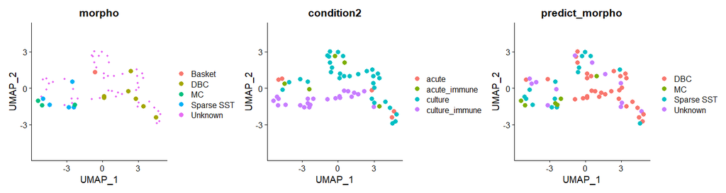

```r
mci4 <- FindClusters(mci4, verbose = FALSE, resolution=1)

a = range(FetchData(mci4,c("UMAP_1","UMAP_2")))
sz = (mci4$morpho!="Unknown")*2+1
p1=ggplot_build(DimPlot(mci4, reduction = "umap", group.by = "morpho",pt.size=sz) + xlim(a) + ylim(a))
p2=ggplot_build(DimPlot(mci4, reduction = "umap", group.by = "condition2",pt.size=3) + xlim(a) + ylim(a))
p3=ggplot_build(DimPlot(mci4, reduction = "umap", group.by = "predict_morpho",pt.size=3) + xlim(a) + ylim(a))
print(p1$plot+p2$plot+p3$plot)
```

Repeat random forest predictions using ephys AND gene expression properties and see how well they agree.

```r
morph <- metadataMCI$morpho
morph[is.element(morph,c("MC","Basket","Sparse SST"))] = "Not DBC"

kp = setdiff(names(keepGenes)[(rownames(datMCI)==make.names(rownames(datMCI)))],all_immune)
dbcGenes <- VariableFeatures(FindVariableFeatures(CreateSeuratObject(datMCI[kp,]),verbose=FALSE,nfeatures = 2500))
datExpr  <- cbind(data.frame(morph=morph),t(datMCI[dbcGenes,]))
datExpr$morph <- droplevels(as.factor(datExpr$morph))

runs         <- 25
predictionsG <- predictionsE <- matrix(NA,nrow = dim(datExpr)[1],ncol=runs)
rownames(predictionsE) <- rownames(predictionsG) <- rownames(datExpr)
ephysDF <- apply(ephys,2,function(x) {x[is.na(x)]=mean(x,na.rm=TRUE); return(x);})
ephysDF <- as.data.frame(ephysDF)[,colSums(is.na(ephys))<25]
ephysDF$morph <- droplevels(as.factor(morph))
ephysDF <- ephysDF[,c("morph",setdiff(colnames(ephysDF),"morph"))]

for (seed in 1:runs){
  set.seed(seed)
  sample <- subsampleCells(datExpr$morph, 3, seed=seed)
  sample[is.element(morph,c("Unknown","Basket"))] = 0

  # Using genes
  train  <- subset(datExpr, sample == 1)
  train$morph <- droplevels(train$morph)
  test   <- subset(datExpr, sample != 1)
  rf     <- randomForest(morph ~ ., data=train, importance=TRUE)
  pred   <- predict(rf, newdata=test[-1])  # the first column is morpho call
  predictionsG[names(pred),seed] = as.character(pred)

  # Using ephys
  train  <- subset(ephysDF, sample == 1)
  train$morph <- droplevels(train$morph)
  test   <- subset(ephysDF, sample != 1)
  rf     <- randomForest(morph ~ ., data=train, importance=TRUE)
  pred   <- predict(rf, newdata=test[-1])  # the first column is morpho call
  predictionsE[names(pred),seed] = as.character(pred)
}
predE  <- apply(predictionsE,1,function(x) names(sort(-table(x)))[1])
scoreE <- apply(predictionsE,1,function(x) max(table(x))/sum(table(x)))
predG  <- apply(predictionsG,1,function(x) names(sort(-table(x)))[1])
scoreG <- apply(predictionsG,1,function(x) max(table(x))/sum(table(x)))
table(morph,predE)
```

```
         predE
morph     DBC Not DBC
  DBC       7       0
  Not DBC   3       6
  Unknown  38      10
```

```r
table(morph,predG)
```

```
         predG
morph     DBC Not DBC
  DBC       5       2
  Not DBC   2       7
  Unknown  33      15
```

```r
table(predG[morph=="Unknown"],predE[morph=="Unknown"])
```

```
          DBC Not DBC
  DBC      26       7
  Not DBC  12       3
```

```r
table(new_prediction[morph=="Unknown"],info$predicted.morpho[morph=="Unknown"])
```

```
             DBC MC Sparse SST
  DBC         14  1          9
  MC           1  0          2
  Sparse SST   6  2          1
  Unknown      6  5          1
```

```r
write.csv(cbind(morphoPred,new_prediction),"cell_morphology_predictions2.csv")
```